# Tutorial: Exploring Random Effects: What Do Participants and Items Tell us Beyond the Fixed Effects?

Jalal Al-Tamimi

Université Paris Cité

13 December 2024

# 1 Loading packages

We start by loading the required packages. If they are not already installed, then the code below will first install them, before loading them. The package `faux` is not available on CRAN for R version 4.4.2, hence we will install it via github. See details [here](https://debruine.github.io/faux/)

```r
requiredPackages = c('tidyverse', 'knitr', 'lme4', 'ggstats', 'ggstatsplot', 'sjPlot', 'paletteer', 'lattice', 'car')

for(p in requiredPackages){
  if(!require(p,character.only = TRUE)) install.packages(p, dependencies = TRUE)
  library(p,character.only = TRUE)
}
```

Specific to the `faux` package

First install the package devtools, and then install the package `faux` via the github install.

```r
# install.packages("devtools")
# devtools::install_github("debruine/faux")
library(faux)
```

# 2 Data set

Our experiment has the following structure: we asked 40 subjects to respond to 40 items in a fully crossed design. There were two IVs: Condition with `congruent` and `incongruent` and Age with `young` and `old`. The Condition is a within subject variable; age is a between subject. However, Condition and Age were both within item variables. The dependant variable was LookingTime.

This meant that we used items within each of the `young` and the `old` subjects in addition to items within each of the `congurent` and `incongruent` conditions.

Our research question is as follows: `Age` of subject will impact the `Looking Time` in the two conditions. Our hypothesis is: The older a subject is, the more the looking time it is to the incongruent condition.

We will use the package `faux` to simulate a dataframe. This step is crucial in assessing contributions of particular predictors and for testing ideas as we already know the distribution of the data and what to expect as an outcome when it comes to the fixed effect in question.

The simulated data has the following parameters

```r
set.seed(42)
# define parameters
Subj_n = 40  # number of subjects
Item_n = 40  # number of items
b0 = 100       # intercept
b1 = 2.5 * b0   # fixed effect of condition
u0s_sd = 300   # random intercept SD for subjects
u0i_sd = 200   # random intercept SD for items
u1s_sd = 100   # random b1 slope SD for subjects
u1i_sd = 50   # random b1 slope SD for items
r01s = -0.3     # correlation between random effects 0 and 1 for subjects
r01i = 0.2     # correlation between random effects 0 and 1 for items
sigma_sd = 150 # error SD

# set up data structure
dataCong <- add_random(Subj = Subj_n, Item = Item_n) %>%
  # add within categorical variable for subject
  add_within("Subj", Cond = c("Congruent", "Incongruent")) %>%
  add_recode("Cond", "Cond.Incongruent", Congruent = 0, Incongruent = 1) %>%
  # add between categorical variable for subject
  add_between("Subj", Age = c("Young", "Old")) %>%
  add_recode("Age", "Age.Old", Young = 0, Old = 1) %>%
  # add random effects
  add_ranef("Subj", u0s = u0s_sd, u1s = u1s_sd, .cors = r01s) %>%
  add_ranef("Item", u0i = u0i_sd, u1i = u1i_sd, .cors = r01i) %>%
  ##add_ranef(c("Subj", "Item"), u0si = u0s_sd + u0i_sd) %>%
  ##add_ranef(c("Subj", "Item"), u1si = u1s_sd + u1i_sd) %>%
  add_ranef(sigma = sigma_sd) %>%
  # calculate DV
  mutate(LookingTime = b0 + b1 + u0s + u0i + #u0si + u1si +
           (((b1 + u1s) + 0.5) * Cond.Incongruent) + (((b1 + u1s) + 0.9) * Age.Old) + # subject specific variation
           (((b1 + u1i) - 0.3) * Cond.Incongruent) + (((b1 + u1i) - 0.25) * Age.Old) + # item specific variation
           sigma)
write.csv(dataCong, "dataCong.csv")
```

If you were not able to install the `faux` package, simply uncomment the following line of code below to import the dataset

```r
#dataCong <- read.csv("dataCong.csv")[-1]
```

# 3 Verify dataframe

## 3.1 Tibble

```r
dataCong <- dataCong %>%
  mutate(Subj = factor(Subj),
         Item = factor(Item))
dataCong
```

| Subj | Item | Cond | Cond.Incongruent | Age | Age.Old | u0s | u1s | u0i | u1i | sigma | LookingTime |
| --- | --- | --- | --- | --- | --- | --- | --- | --- | --- | --- | --- |
| Subj01 | Item01 | Congruent | 0 | Young | 0 | -413.19481 | 26.24753 | -306.396712 | 56.883622 | -26.32888054 | -395.9203996 |
| Subj01 | Item01 | Incongruent | 1 | Young | 0 | -413.19481 | 26.24753 | -306.396712 | 56.883622 | -160.76735762 | 52.9722725 |
| Subj01 | Item02 | Congruent | 0 | Young | 0 | -413.19481 | 26.24753 | -55.400523 | 69.096087 | 24.48103237 | -94.1142986 |
| Subj01 | Item02 | Incongruent | 1 | Young | 0 | -413.19481 | 26.24753 | -55.400523 | 69.096087 | -54.41076234 | 422.5375210 |
| Subj01 | Item03 | Congruent | 0 | Young | 0 | -413.19481 | 26.24753 | -17.362543 | -7.033043 | 88.50203220 | 7.9446821 |
| Subj01 | Item03 | Incongruent | 1 | Young | 0 | -413.19481 | 26.24753 | -17.362543 | -7.033043 | 214.86328916 | 653.7204228 |
| Subj01 | Item04 | Congruent | 0 | Young | 0 | -413.19481 | 26.24753 | 21.587729 | 49.977357 | -148.90387667 | -190.5109549 |
| Subj01 | Item04 | Incongruent | 1 | Young | 0 | -413.19481 | 26.24753 | 21.587729 | 49.977357 | 68.19754464 | 603.0153499 |
| Subj01 | Item05 | Congruent | 0 | Young | 0 | -413.19481 | 26.24753 | 238.840885 | 12.791449 | 12.73470880 | 188.3807865 |
| Subj01 | Item05 | Incongruent | 1 | Young | 0 | -413.19481 | 26.24753 | 238.840885 | 12.791449 | 134.33483734 | 849.2198911 |

[output cut: 990 more lines]

## 3.2 Counts

### 3.2.1 Subjects

```r
dataCong %>%
  group_by(Cond, Age, Subj) %>%
  summarise(count = n())
```

| Cond | Age | Subj | count |
| --- | --- | --- | --- |
| Congruent | Young | Subj01 | 40 |
| Congruent | Young | Subj03 | 40 |
| Congruent | Young | Subj05 | 40 |
| Congruent | Young | Subj07 | 40 |
| Congruent | Young | Subj09 | 40 |
| Congruent | Young | Subj11 | 40 |
| Congruent | Young | Subj13 | 40 |
| Congruent | Young | Subj15 | 40 |
| Congruent | Young | Subj17 | 40 |
| Congruent | Young | Subj19 | 40 |

[output cut: 70 more lines]

### 3.2.2 Items

#### 3.2.2.1 Age

```r
dataCong %>%
  group_by(Age, Item) %>%
  summarise(count = n())
```

| Age | Item | count |
| --- | --- | --- |
| Young | Item01 | 40 |
| Young | Item02 | 40 |
| Young | Item03 | 40 |
| Young | Item04 | 40 |
| Young | Item05 | 40 |
| Young | Item06 | 40 |
| Young | Item07 | 40 |
| Young | Item08 | 40 |
| Young | Item09 | 40 |
| Young | Item10 | 40 |

[output cut: 70 more lines]

#### 3.2.2.2 Cond

```r
dataCong %>%
  group_by(Cond, Item) %>%
  summarise(count = n())
```

| Cond | Item | count |
| --- | --- | --- |
| Congruent | Item01 | 40 |
| Congruent | Item02 | 40 |
| Congruent | Item03 | 40 |
| Congruent | Item04 | 40 |
| Congruent | Item05 | 40 |
| Congruent | Item06 | 40 |
| Congruent | Item07 | 40 |
| Congruent | Item08 | 40 |
| Congruent | Item09 | 40 |
| Congruent | Item10 | 40 |

[output cut: 70 more lines]

# 4 Visualisations

## 4.1 Condition by Age

The figure below confirms this, where we see an increase in LookingTime in the `incongruent` condition and oevrall, `older` participants show an increase in LookingTime

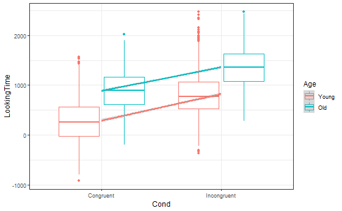

```r
dataCong %>%
  ggplot(aes(x = Cond,
             y = LookingTime,
             colour = Age)) +
  theme_bw() +
  geom_boxplot() +
  geom_smooth(aes(as.numeric(Cond)), method = "lm")
```

## 4.2 Subject by Condition

This figure shows that subjects are variable in how they responded to this task

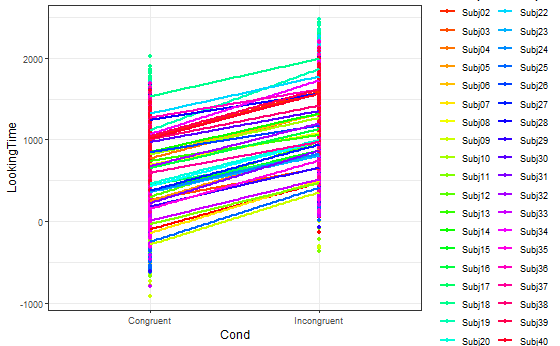

```r
dataCong %>%
  ggplot(aes(x = Cond,
             y = LookingTime,
             colour = Subj)) +
  theme_bw() +
  geom_point() +
  geom_smooth(aes(as.numeric(Cond)), method = "lm", se = FALSE) +
  scale_colour_manual(values = paletteer_c("grDevices::rainbow", length(unique(dataCong$Subj))))
```

## 4.3 Subject by Age

This figure shows that subjects had an impact on the LookingTime in both age groups, simply due to their variable responses to the different items

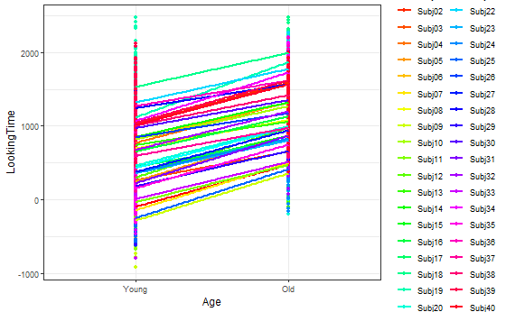

```r
dataCong %>%
  ggplot(aes(x = Age,
             y = LookingTime,
             colour = Subj)) +
  theme_bw() +
  geom_point() +
  geom_smooth(aes(as.numeric(Cond)), method = "lm", se = FALSE) +
  scale_colour_manual(values = paletteer_c("grDevices::rainbow", length(unique(dataCong$Subj))))
```

## 4.4 Item by Condition

This figure shows that items had an impact on the LookingTime in both conditions

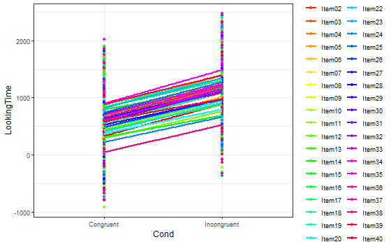

```r
dataCong %>%
  ggplot(aes(x = Cond,
             y = LookingTime,
             colour = Item)) +
  theme_bw() +
  geom_point() +
  geom_smooth(aes(as.numeric(Cond)), method = "lm", se = FALSE) +
  scale_colour_manual(values = paletteer_c("grDevices::rainbow", length(unique(dataCong$Item))))
```

This figure shows that items had an impact on the LookingTime in both age groups

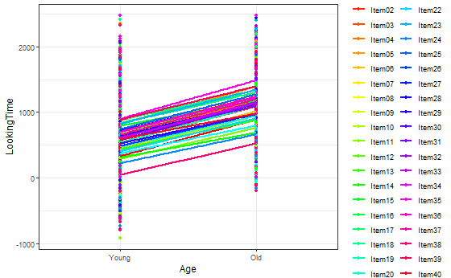

```r
dataCong %>%
  ggplot(aes(x = Age,
             y = LookingTime,
             colour = Item)) +
  theme_bw() +
  geom_point() +
  geom_smooth(aes(as.numeric(Cond)), method = "lm", se = FALSE) +
  scale_colour_manual(values = paletteer_c("grDevices::rainbow", length(unique(dataCong$Item))))
```

# 5 Modelling strategy

We use an LMER model with a crossed random effect. To choose our optimal model, we start first by a simple model with only random intercepts, increasing complexity by accounting for random slopes for both subjects and items. It is clear from our visualisation above, that there is no interaction between the two predictors. However, for demonstration purposes, we do test for this

# 6 Simple Linear Model

```r
mdl.lm <- dataCong %>%
  lm(LookingTime ~ Cond + Age, data = .)
summary(mdl.lm)
```

```
Call:
lm(formula = LookingTime ~ Cond + Age, data = .)

Residuals:
     Min       1Q   Median       3Q      Max
-1215.59  -290.17   -21.78   264.89  1661.41

Coefficients:
                Estimate Std. Error t value Pr(>|t|)
(Intercept)       304.95      12.91   23.61   <2e-16 ***
CondIncongruent   504.35      14.91   33.82   <2e-16 ***
AgeOld            566.44      14.91   37.98   <2e-16 ***
---
Signif. codes:  0 ‘***’ 0.001 ‘**’ 0.01 ‘*’ 0.05 ‘.’ 0.1 ‘ ’ 1

Residual standard error: 421.8 on 3197 degrees of freedom
Multiple R-squared:  0.4472,    Adjusted R-squared:  0.4469
F-statistic:  1293 on 2 and 3197 DF,  p-value: < 2.2e-16
```

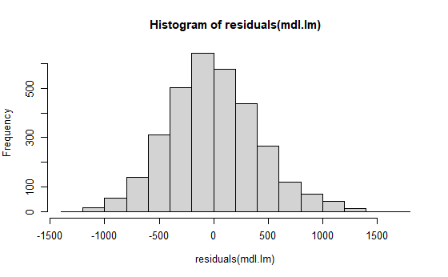

```r
hist(residuals(mdl.lm))
```

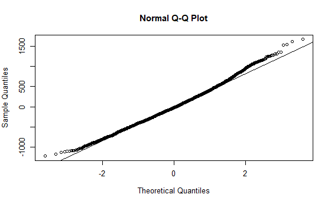

```r
qqnorm(residuals(mdl.lm)); qqline(residuals(mdl.lm))
```

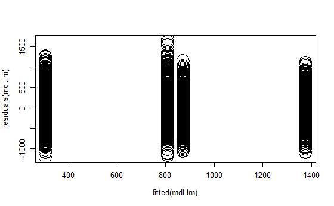

```r
plot(fitted(mdl.lm), residuals(mdl.lm), cex = 4)
```

## 6.1 No interaction

### 6.1.1 Crossed random intercepts

```r
xmdl.rand.Interc <- dataCong %>%
  lmer(LookingTime ~ Cond + Age +
         (1 | Subj) +
         (1 | Item), data = ., REML = FALSE,
       control = lmerControl(optimizer = "bobyqa", optCtrl = list(maxfun = 1e5)))
```

### 6.1.2 Crossed random intercepts + By-speaker random slopes

```r
xmdl.rand.Slope1 <- dataCong %>%
  lmer(LookingTime ~ Cond + Age +
         (1 + Cond | Subj) +
         (1 | Item), data = ., REML = FALSE,
       control = lmerControl(optimizer = "bobyqa", optCtrl = list(maxfun = 1e5)))
```

### 6.1.3 Crossed random intercepts + By-speaker and by-item random slopes

```r
xmdl.rand.Slope2 <- dataCong %>%
  lmer(LookingTime ~ Cond + Age +
         (1 + Cond | Subj) +
         (1 + Cond | Item), data = ., REML = FALSE,
       control = lmerControl(optimizer = "bobyqa", optCtrl = list(maxfun = 1e5)))
```

### 6.1.4 Crossed random intercepts + By-speaker and by-item random slopes

```r
xmdl.rand.Slope3 <- dataCong %>%
  lmer(LookingTime ~ Cond + Age +
         (1 + Cond | Subj) +
         (1 + Cond + Age| Item), data = ., REML = FALSE,
       control = lmerControl(optimizer = "bobyqa", optCtrl = list(maxfun = 1e5)))
```

## 6.2 With interaction

### 6.2.1 Crossed random intercepts + Interaction

```r
xmdl.rand.Interc.Int <- dataCong %>%
  lmer(LookingTime ~ Cond * Age +
         (1 | Subj) +
         (1 | Item), data = ., REML = FALSE,
       control = lmerControl(optimizer = "bobyqa", optCtrl = list(maxfun = 1e5)))
```

### 6.2.2 Crossed random intercepts + By-speaker random slopes + Interaction

```r
xmdl.rand.Slope1.Int <- dataCong %>%
  lmer(LookingTime ~ Cond * Age +
         (1 + Cond | Subj) +
         (1 | Item), data = ., REML = FALSE,
       control = lmerControl(optimizer = "bobyqa", optCtrl = list(maxfun = 1e5)))
```

### 6.2.3 Crossed random intercepts + By-speaker and by-item random slopes + Interaction

```r
xmdl.rand.Slope2.Int <- dataCong %>%
  lmer(LookingTime ~ Cond * Age +
         (1 + Cond | Subj) +
         (1 + Cond | Item), data = ., REML = FALSE,
       control = lmerControl(optimizer = "bobyqa", optCtrl = list(maxfun = 1e5)))
```

### 6.2.4 Crossed random intercepts + By-speaker and by-item random slopes

```r
xmdl.rand.Slope3.Int <- dataCong %>%
  lmer(LookingTime ~ Cond * Age +
         (1 + Cond | Subj) +
         (1 + Cond * Age| Item), data = ., REML = FALSE,
       control = lmerControl(optimizer = "bobyqa", optCtrl = list(maxfun = 1e5)))
```

## 6.3 Model comparison

```r
anova(xmdl.rand.Interc, xmdl.rand.Slope1, xmdl.rand.Slope2, xmdl.rand.Slope3, xmdl.rand.Interc.Int, xmdl.rand.Slope1.Int, xmdl.rand.Slope2.Int, xmdl.rand.Slope3.Int)
```

```
Data: .
Models:
xmdl.rand.Interc: LookingTime ~ Cond + Age + (1 | Subj) + (1 | Item)
xmdl.rand.Interc.Int: LookingTime ~ Cond * Age + (1 | Subj) + (1 | Item)
xmdl.rand.Slope1: LookingTime ~ Cond + Age + (1 + Cond | Subj) + (1 | Item)
xmdl.rand.Slope1.Int: LookingTime ~ Cond * Age + (1 + Cond | Subj) + (1 | Item)
xmdl.rand.Slope2: LookingTime ~ Cond + Age + (1 + Cond | Subj) + (1 + Cond | Item)
xmdl.rand.Slope2.Int: LookingTime ~ Cond * Age + (1 + Cond | Subj) + (1 + Cond | Item)
xmdl.rand.Slope3: LookingTime ~ Cond + Age + (1 + Cond | Subj) + (1 + Cond + Age | Item)
xmdl.rand.Slope3.Int: LookingTime ~ Cond * Age + (1 + Cond | Subj) + (1 + Cond * Age | Item)
                     npar   AIC   BIC logLik deviance    Chisq Df Pr(>Chisq)
xmdl.rand.Interc        6 42074 42110 -21031    42062
xmdl.rand.Interc.Int    7 42050 42093 -21018    42036  25.8359  1  3.717e-07 ***
xmdl.rand.Slope1        8 41834 41883 -20909    41818 217.8699  1  < 2.2e-16 ***
xmdl.rand.Slope1.Int    9 41833 41888 -20908    41815   3.0247  1     0.0820 .
xmdl.rand.Slope2       10 41808 41869 -20894    41788  27.3253  1  1.719e-07 ***
xmdl.rand.Slope2.Int   11 41807 41874 -20892    41785   3.0149  1     0.0825 .
xmdl.rand.Slope3       13 41780 41858 -20877    41754  31.2599  2  1.629e-07 ***
xmdl.rand.Slope3.Int   18 41786 41895 -20875    41750   3.3401  5     0.6477
---
Signif. codes:  0 ‘***’ 0.001 ‘**’ 0.01 ‘*’ 0.05 ‘.’ 0.1 ‘ ’ 1
```

# 7 Optimal model

```r
xmdl.Optimal <- dataCong %>%
  lmer(LookingTime ~ Cond + Age +
         (1 + Cond | Subj) +
         (1 + Cond + Age | Item), data = ., REML = TRUE,
       control = lmerControl(optimizer = "bobyqa", optCtrl = list(maxfun = 1e5)))
```

## 7.1 Model criticism

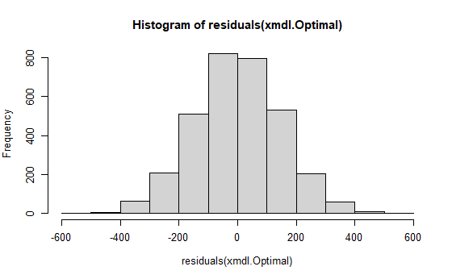

```r
hist(residuals(xmdl.Optimal))
```

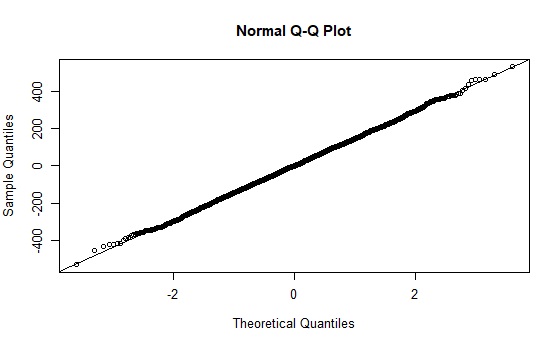

```r
qqnorm(residuals(xmdl.Optimal)); qqline(residuals(xmdl.Optimal))
```

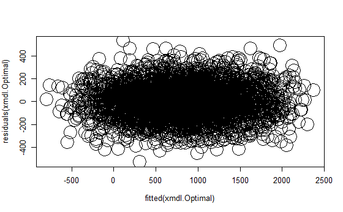

```r
plot(fitted(xmdl.Optimal), residuals(xmdl.Optimal), cex = 4)
```

## 7.2 Summary

```r
xmdl.Optimal %>%
  summary()
```

```
Linear mixed model fit by REML ['lmerMod']
Formula: LookingTime ~ Cond + Age + (1 + Cond | Subj) + (1 + Cond + Age |      Item)
   Data: .
Control: lmerControl(optimizer = "bobyqa", optCtrl = list(maxfun = 1e+05))

REML criterion at convergence: 41724.6

Scaled residuals:
    Min      1Q  Median      3Q     Max
-3.5337 -0.6485 -0.0054  0.6647  3.5358

Random effects:
 Groups   Name            Variance Std.Dev. Corr
 Subj     (Intercept)     123480   351.40
          CondIncongruent  10746   103.66   -0.26
 Item     (Intercept)      38781   196.93
          CondIncongruent   1872    43.27    0.31
          AgeOld            1851    43.03   -0.13  0.69
 Residual                  22613   150.38
Number of obs: 3200, groups:  Subj, 40; Item, 40

Fixed effects:
                Estimate Std. Error t value
(Intercept)       315.04      83.42   3.777
CondIncongruent   504.35      18.54  27.204
AgeOld            546.28     107.70   5.072

Correlation of Fixed Effects:
            (Intr) CndInc
CndIncngrnt -0.120
AgeOld      -0.646  0.016
```

## 7.3 ANOVA

```r
Anova(xmdl.Optimal)
```

```
Analysis of Deviance Table (Type II Wald chisquare tests)

Response: LookingTime
       Chisq Df Pr(>Chisq)
Cond 740.067  1  < 2.2e-16 ***
Age   25.729  1  3.928e-07 ***
---
Signif. codes:  0 ‘***’ 0.001 ‘**’ 0.01 ‘*’ 0.05 ‘.’ 0.1 ‘ ’ 1
```

## 7.4 Plotting model’s output

### 7.4.1 With `ggstats`

We use two functions from the package `ggstats`.

#### 7.4.1.1 A plot

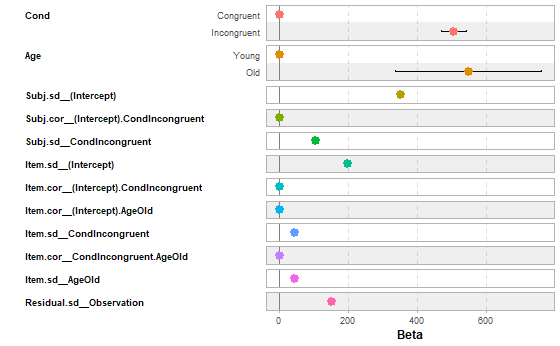

```r
ggcoef_model(xmdl.Optimal)
```

### 7.4.2 A plot + a table + 95% CI

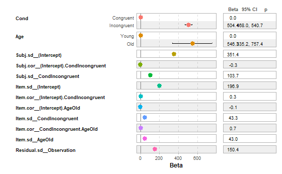

```r
ggcoef_table(xmdl.Optimal)
```

### 7.4.3 With `ggstatsplot`

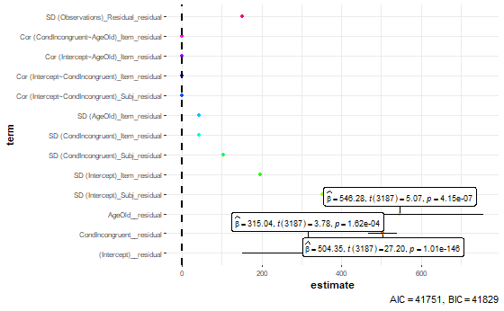

```r
ggcoefstats(xmdl.Optimal, point.args = list(color = paletteer_c("grDevices::rainbow", 13), stats.label.color = paletteer_c("grDevices::rainbow", 13)))
```

## 7.5 Exploring random effects

### 7.5.1 Subject random effects

```r
random_effects <- ranef(xmdl.Optimal) %>%
  pluck(1) %>%
  rownames_to_column() %>%
  rename(Subject = rowname, Intercept = "(Intercept)")

random_effects %>%
  knitr::kable()
```

| Subject | Intercept | CondIncongruent |
| --- | --- | --- |
| Subj01 | -404.45054 | 58.1953368 |
| Subj02 | 164.05584 | 56.9126271 |
| Subj03 | -56.37438 | -104.0600477 |
| Subj04 | -87.06837 | 43.7884729 |
| Subj05 | -55.65214 | 104.5323900 |
| Subj06 | -42.39999 | -7.1394328 |
| Subj07 | -448.81496 | 124.6524549 |
| Subj08 | -171.75810 | -105.4504187 |
| Subj09 | -587.74594 | 123.6911001 |
| Subj10 | -44.50407 | -50.9618431 |
| Subj11 | -346.46288 | 1.6396966 |
| Subj12 | -550.49633 | 158.6524706 |
| Subj13 | 417.66027 | -169.1409700 |
| Subj14 | -11.45716 | -30.0008252 |
| Subj15 | 62.46659 | -14.3520076 |
| Subj16 | -210.03389 | -23.9077430 |
| Subj17 | 124.19946 | -122.7635167 |
| Subj18 | 666.67147 | -42.1836697 |
| Subj19 | 815.78333 | 217.1615447 |
| Subj20 | -393.58521 | 26.1633665 |
| Subj21 | 120.64645 | 37.9297097 |
| Subj22 | 455.31816 | -46.4925696 |
| Subj23 | 42.42431 | -54.4053551 |
| Subj24 | -496.29436 | -31.7202386 |
| Subj25 | -552.91357 | 144.2714898 |
| Subj26 | -21.91509 | -159.7897817 |
| Subj27 | 65.14521 | 54.5212747 |
| Subj28 | 373.40089 | -166.0862255 |
| Subj29 | -132.82108 | -21.8820276 |
| Subj30 | 104.73419 | -112.8914459 |
| Subj31 | -79.72260 | 125.0118699 |
| Subj32 | -182.30982 | 15.3898936 |
| Subj33 | -303.68384 | -0.1957386 |
| Subj34 | 215.98609 | 136.5078869 |
| Subj35 | -152.60397 | 76.5559812 |
| Subj36 | 401.50547 | -145.0045141 |
| Subj37 | 274.61818 | -114.4122298 |
| Subj38 | 139.48473 | -82.7958618 |
| Subj39 | 733.87830 | 58.5575032 |
| Subj40 | 155.08935 | 41.5013939 |

```r
NA
```

### 7.5.2 Items random effects

```r
random_effects <- ranef(xmdl.Optimal) %>%
  pluck(2) %>%
  rownames_to_column() %>%
  rename(Items = rowname, Intercept = "(Intercept)")

random_effects %>%
  knitr::kable()
```

| Items | Intercept | CondIncongruent | AgeOld |
| --- | --- | --- | --- |
| Item01 | -247.414507 | 16.2991489 | 28.312990 |
| Item02 | -28.240445 | 20.6149279 | 37.267856 |
| Item03 | -27.548429 | 11.7099339 | -3.218254 |
| Item04 | 30.999046 | 32.2392558 | 32.548236 |
| Item05 | 246.216859 | 38.0585978 | 2.963549 |
| Item06 | -135.583736 | 28.3151555 | 28.127356 |
| Item07 | 75.461498 | 28.6715548 | -2.095288 |
| Item08 | 72.679400 | 69.1730999 | 73.479523 |
| Item09 | -180.071444 | 32.9237845 | 60.953057 |
| Item10 | -170.029328 | 8.4112590 | 23.865843 |
| Item11 | -278.857705 | -39.6392919 | -22.526611 |
| Item12 | 114.001985 | 4.7652485 | -15.353357 |
| Item13 | -137.533542 | -49.5701246 | -36.764423 |
| Item14 | -272.928912 | -85.2576750 | -45.340742 |
| Item15 | 219.855541 | -70.2475223 | -83.121735 |
| Item16 | 243.071753 | 13.0287924 | -4.812872 |
| Item17 | 210.792625 | 10.6898312 | 17.840004 |
| Item18 | 328.737750 | -36.9498461 | -82.922663 |
| Item19 | -46.910049 | 28.2829527 | 22.930110 |
| Item20 | -107.870056 | -25.5384308 | -13.846115 |
| Item21 | -209.598744 | -56.8339801 | -29.482588 |
| Item22 | -190.253581 | -3.0439700 | 20.502593 |
| Item23 | 207.958662 | 34.4328035 | 33.373202 |
| Item24 | -371.211245 | -46.1955836 | 1.751542 |
| Item25 | 163.603914 | 15.0837752 | -7.780876 |
| Item26 | -56.954235 | -39.1972201 | -59.652416 |
| Item27 | 126.648406 | 7.5867262 | -1.102683 |
| Item28 | 48.176096 | -0.4969082 | 1.358911 |
| Item29 | -76.699978 | -27.4397677 | -1.462473 |
| Item30 | -20.393146 | 33.1813806 | 36.286219 |
| Item31 | 33.763413 | -15.9993987 | -14.400133 |
| Item32 | -15.979008 | 47.9237115 | 67.643383 |
| Item33 | 64.451213 | -8.2252951 | -47.157817 |
| Item34 | 102.286457 | 22.6554454 | 17.134672 |
| Item35 | 319.882212 | 54.1470278 | 10.485257 |
| Item36 | 115.886689 | 22.7596669 | 9.094458 |
| Item37 | 93.471368 | 9.1514824 | -17.490313 |
| Item38 | -523.293815 | -46.1545897 | -5.185309 |
| Item39 | 287.858945 | 20.0462752 | 2.292928 |
| Item40 | -8.431927 | -59.3622338 | -34.495018 |

```r
NA
```

### 7.5.3 Plots

#### 7.5.3.1 sjPlot

##### 7.5.3.1.1 Fixed effects

###### 7.5.3.1.1.1 Condition

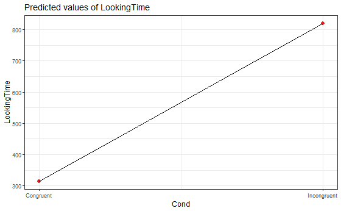

```r
plot_model(xmdl.Optimal, type="pred", terms=c("Cond"), ci.lvl = NA, dodge = 0) + theme_bw() + geom_line()
```

###### 7.5.3.1.1.2 Age

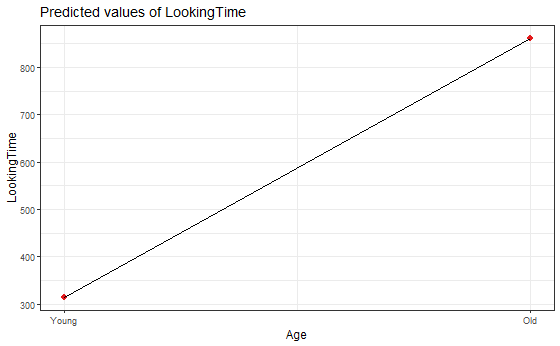

```r
plot_model(xmdl.Optimal, type="pred", terms=c("Age"), ci.lvl = NA, dodge = 0) + theme_bw() + geom_line()
```

###### 7.5.3.1.1.3 Condition by Age

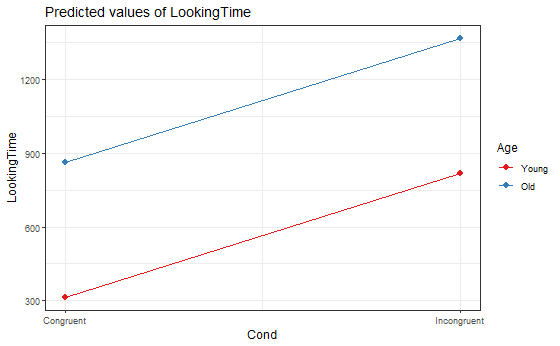

```r
plot_model(xmdl.Optimal, type="emm", terms=c("Cond", "Age"), ci.lvl = NA, dodge = 0) + theme_bw() + geom_line()
```

##### 7.5.3.1.2 Random effects

###### 7.5.3.1.2.1 Subject

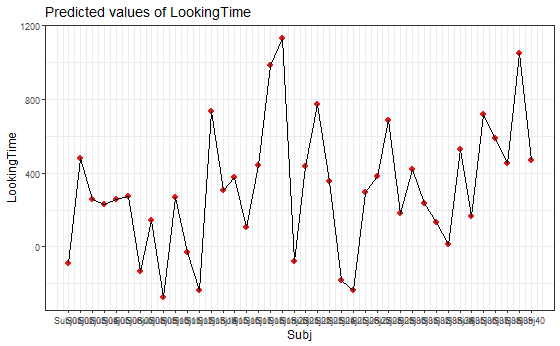

```r
plot_model(xmdl.Optimal, type="pred", terms=c("Subj"), pred.type="re", ci.lvl = NA, dodge = 0) + theme_bw() + geom_line()
```

###### 7.5.3.1.2.2 Subject by Condition

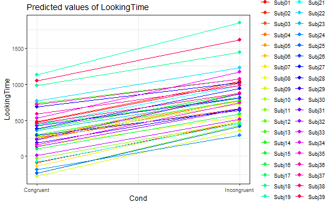

```r
plot_model(xmdl.Optimal, type="pred", terms=c("Cond", "Subj"), pred.type="re", ci.lvl = NA, dodge = 0, colors = paletteer_c("grDevices::rainbow", length(unique(dataCong$Subj)))) + theme_bw() + geom_line()
```

###### 7.5.3.1.2.3 Subject by Age

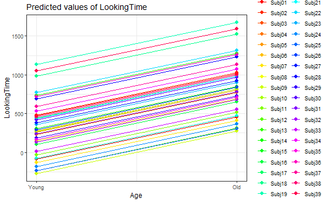

```r
plot_model(xmdl.Optimal, type="pred", terms=c("Age", "Subj"), pred.type="re", ci.lvl = NA, dodge = 0, colors = paletteer_c("grDevices::rainbow", length(unique(dataCong$Subj)))) + theme_bw() + geom_line()
```

###### 7.5.3.1.2.4 Item

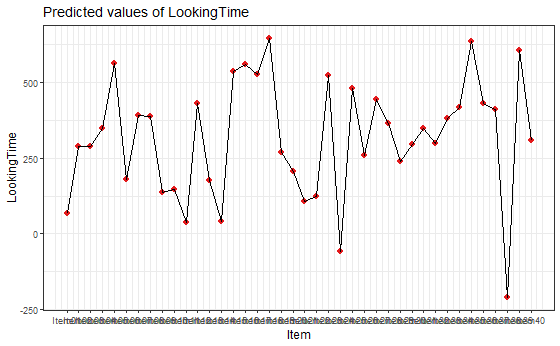

```r
plot_model(xmdl.Optimal, type="pred", terms=c("Item"), pred.type="re", ci.lvl = NA, dodge = 0) + theme_bw() + geom_line()
```

###### 7.5.3.1.2.5 Item by Cond

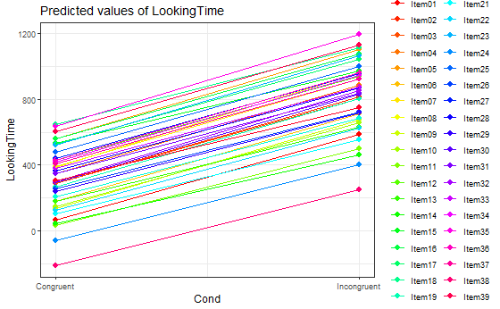

```r
plot_model(xmdl.Optimal, type="pred", terms=c("Cond", "Item"), pred.type="re", ci.lvl = NA, dodge = 0, colors = paletteer_c("grDevices::rainbow", length(unique(dataCong$Item)))) + theme_bw() + geom_line()
```

###### 7.5.3.1.2.6 Item by Age

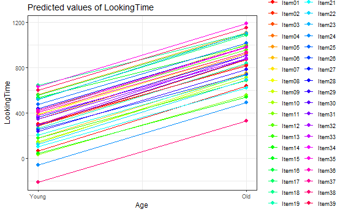

```r
plot_model(xmdl.Optimal, type="pred", terms=c("Age", "Item"), pred.type="re", ci.lvl = NA, dodge = 0, colors = paletteer_c("grDevices::rainbow", length(unique(dataCong$Item)))) + theme_bw() + geom_line()
```

###### 7.5.3.1.2.7 Item by Cond facetted by Age

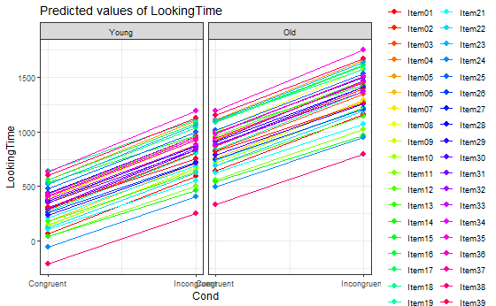

```r
plot_model(xmdl.Optimal, type="pred", terms=c("Cond", "Item", "Age"), pred.type="re", ci.lvl = NA, dodge = 0, colors = paletteer_c("grDevices::rainbow", length(unique(dataCong$Item)))) + theme_bw() + geom_line()
```

###### 7.5.3.1.2.8 Subject by Item

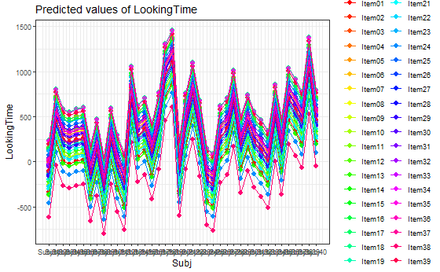

```r
plot_model(xmdl.Optimal, type="pred", terms=c("Subj", "Item"), pred.type="re", ci.lvl = NA, dodge = 0, colors = paletteer_c("grDevices::rainbow", length(unique(dataCong$Subj)))) + theme_bw() + geom_line()
```

###### 7.5.3.1.2.9 Subject by Item facetted by Cond

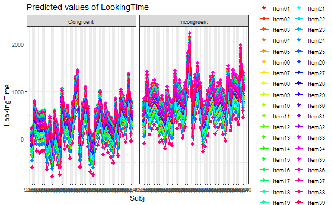

```r
plot_model(xmdl.Optimal, type="pred", terms=c("Subj", "Item", "Cond"), pred.type="re", ci.lvl = NA, dodge = 0, colors = paletteer_c("grDevices::rainbow", length(unique(dataCong$Subj)))) + theme_bw() + geom_line()
```

###### 7.5.3.1.2.10 Subject by Item facetted by Age

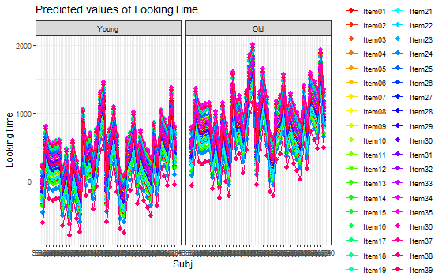

```r
plot_model(xmdl.Optimal, type="pred", terms=c("Subj", "Item", "Age"), pred.type="re", ci.lvl = NA, dodge = 0, colors = paletteer_c("grDevices::rainbow", length(unique(dataCong$Subj)))) + theme_bw() + geom_line()
```

#### 7.5.3.2 Lattice

##### 7.5.3.2.1 Subject Intercepts

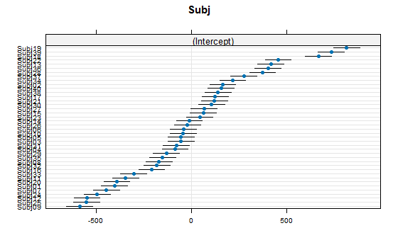

```r
dotplot(ranef(xmdl.Optimal))$Subj[1]
```

##### 7.5.3.2.2 Subject Slopes

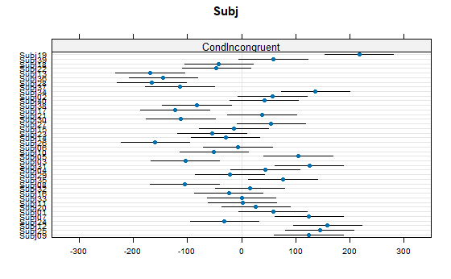

```r
dotplot(ranef(xmdl.Optimal), xlim = c(-350, 350))$Subj[2]
```

##### 7.5.3.2.3 Item Intercepts

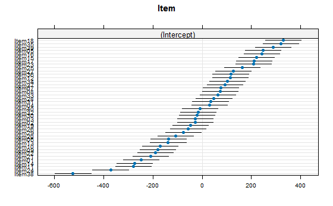

```r
dotplot(ranef(xmdl.Optimal))$Item[1]
```

##### 7.5.3.2.4 Item Slopes for Cond

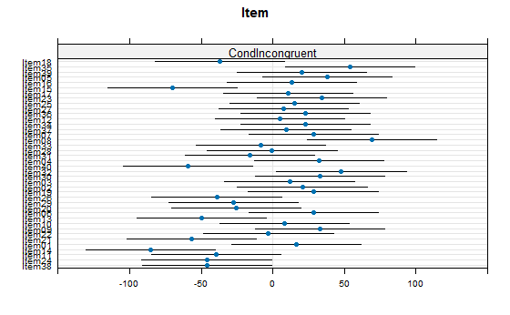

```r
dotplot(ranef(xmdl.Optimal), xlim = c(-150, 150))$Item[2]
```

##### 7.5.3.2.5 Item Slopes for Age

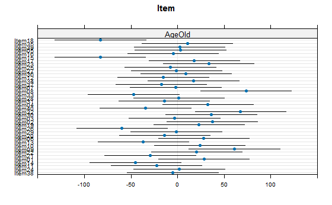

```r
dotplot(ranef(xmdl.Optimal), xlim = c(-150, 150))$Item[3]
```

# 8 Conclusion

This tutorial showed how one can explore random effects and formally assess the need for Random slopes

As a rule of thumb: Any within-subject (or within-item) should be tested for a potential inclusion as a random slope

Fixed effects provides averages over all observations, even when using mixed effects regressions; we need to explore what random effects (intercepts and slopes) tell us.

In this example, we see that many subjects vary beyond the fixed effect; Standard Errors are not enough to quantify this type of variation. The same is true for items that are not explored routinely!

I hope this tutorial helped you to uncover the role of participants and items and what they can tell us beyond the fixed effect!